# HW5: Classification and Representation (due 1/9 23:30)

## Problem 1: Fault Classification

This problem concerns about the quality of a casting item. This data set collects the images (100x100 pixels) of 6633 items, together with their quality labels (defective or ok).

The objective is to predict the label (defect or ok) of each image.

### Your analysis should include the following:

- The training procedures of the classifiers (at least 2 different classifiers), and their performance comparisons.
- A brief analysis summary.
- (Bonus) Can defect items (image data) be clustered with patterns (sub-types)? Explore your findings.

### Read image into data frame

```r
#install required packages
library("jpeg")
library("plyr")

setwd("casting_100x100")

def_paths <- dir("def_front")
ok_paths <- dir("ok_front")

data_def = sapply(1:length(def_paths), function(x){
  tmp = readJPEG(paste0("def_front/", def_paths[x]))[,,1]
  tmp = as.vector(tmp)
  return(tmp)
})

data_ok = sapply(1:length(ok_paths), function(x){
  tmp = readJPEG(paste0("ok_front/", ok_paths[x]))[,,1]
  tmp = as.vector(tmp)
  return(tmp)
})

data = as.data.frame(rbind(t(data_def), t(data_ok)))
data$y = as.factor(c(rep(1,length(def_paths)), rep(0,length(ok_paths))))
dim(data)
```

```
## [1]  6633 10001
```

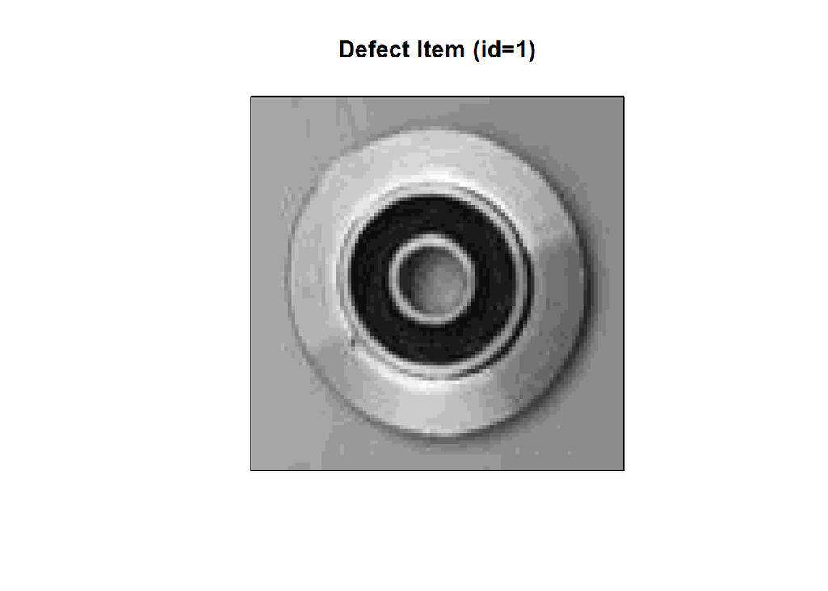

```r
## Data Preprocessing

show_image = function(img_cast, col = gray(1:20/20), ...){
  image(matrix(as.matrix(img_cast), ncol = 100, byrow = TRUE)[, 100:1], col = col, ...)
}

## show images for a defect item and a good (OK) item
par(mfrow = c(1,1), pty="s")
show_image(data[1,-10001], col = gray(1:20/20), axes=F); box(); title("Defect Item (id=1)")
```

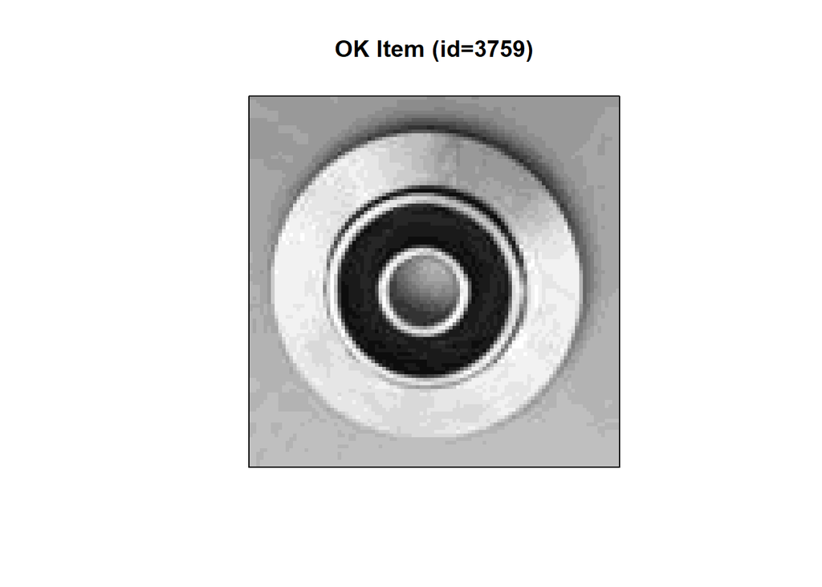

```r
show_image(data[length(def_paths)+1,-10001], col = gray(1:20/20), axes=F); box(); title("OK Item (id=3759)")
```

## Problem 2: Forecast for SP500 returns

This problem concerns about 2 tasks on forecasting the return for SP500:

- Task 1 (regression): forecast the daily return value;
- Task 2 (classification): forecast the trend (“up” if return greater than zero; or “down” otherwise).

The data can be retrieved from yahoo into R via the function `getSymbols` in `quantmod` package. In this homework, we take the data before 2021/12/31 as the training data; and the data after 2022/1/1 as the testing data.

You may replace the SP500 returns by any other return series of your interest for this problem.

### Your analysis should include the following:

- The training procedures of the predictive models for both tasks. (training period: before 2022)
- Summarize the prediction performance in the testing period (2022/1/1-2022/12/31).

### Get data

```r
#install required package

library(quantmod)

getSymbols("SPY", src = "yahoo", from = as.Date("2010-01-01"), to = as.Date("2021-12-31"))
```

```
## [1] "SPY"
```

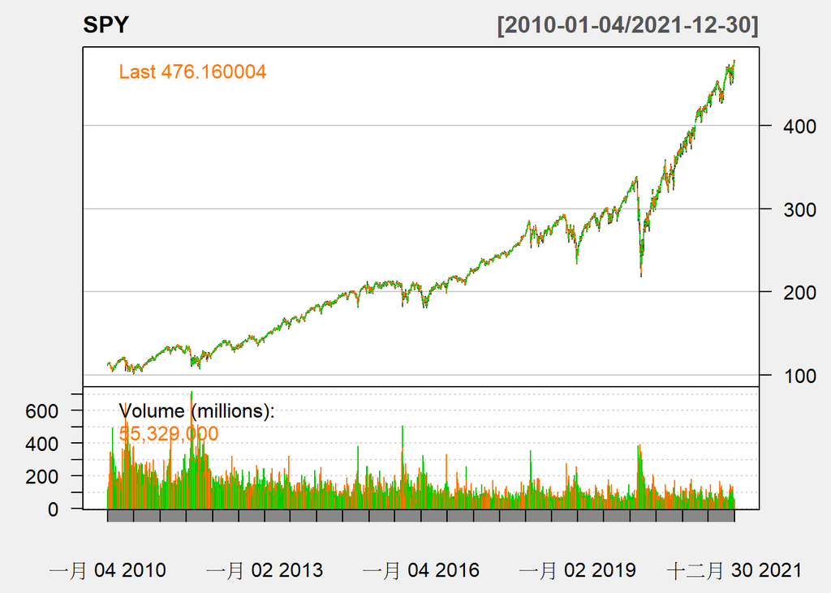

```r
chartSeries(SPY, theme = chartTheme("white"))
```

```r
head(SPY);
```

```
##            SPY.Open SPY.High SPY.Low SPY.Close SPY.Volume SPY.Adjusted
## 2010-01-04   112.37   113.39  111.51    113.33  118944600     88.45418
## 2010-01-05   113.26   113.68  112.85    113.63  111579900     88.68837
## 2010-01-06   113.52   113.99  113.43    113.71  116074400     88.75079
## 2010-01-07   113.50   114.33  113.18    114.19  131091100     89.12543
## 2010-01-08   113.89   114.62  113.66    114.57  126402800     89.42200
## 2010-01-11   115.08   115.13  114.24    114.73  106375700     89.54689
```

```r
tail(SPY)
```

```
##            SPY.Open SPY.High SPY.Low SPY.Close SPY.Volume SPY.Adjusted
## 2021-12-22   462.79   467.81  462.58    467.69   58890200     460.2236
## 2021-12-23   468.75   472.19  468.64    470.60   56439700     463.0872
## 2021-12-27   472.06   477.31  472.01    477.26   56808600     469.6409
## 2021-12-28   477.72   478.81  476.06    476.87   47274600     469.2570
## 2021-12-29   476.98   478.56  475.92    477.48   54503000     469.8574
## 2021-12-30   477.93   479.00  475.67    476.16   55329000     468.5584
```

```r
# compute daily returns:
rr <- exp(diff(log(SPY$SPY.Close)))-1
Direction <- ifelse(rr >= 0, "Up", "Down")
names(Direction) <- "Direction"

# create lag variables (you may use more lags or other info from SPY object)
rr.Lag <- Lag(rr, 1:5)
Volume.Lag <- Lag(SPY$SPY.Volume,1:5)

#For Task 1 (respones variable: rr):
SPY.return <- data.frame(rr, rr.Lag, Volume.Lag/10^9) #rescale Volume such that all scales are comparable!
names(SPY.return) <- c("r", "r.Lag.1", "r.Lag.2", "r.Lag.3",  "r.Lag.4", "r.Lag.5",
                            "v.Lag.1", "v.Lag.2", "v.Lag.3",  "v.Lag.4", "v.Lag.5")

head(SPY.return)
```

```
##                      r     r.Lag.1     r.Lag.2     r.Lag.3     r.Lag.4 r.Lag.5
## 2010-01-04          NA          NA          NA          NA          NA      NA
## 2010-01-05 0.002647093          NA          NA          NA          NA      NA
## 2010-01-06 0.000704057 0.002647093          NA          NA          NA      NA
## 2010-01-07 0.004221291 0.000704057 0.002647093          NA          NA      NA
## 2010-01-08 0.003327769 0.004221291 0.000704057 0.002647093          NA      NA
## 2010-01-11 0.001396552 0.003327769 0.004221291 0.000704057 0.002647093      NA
##              v.Lag.1   v.Lag.2   v.Lag.3   v.Lag.4   v.Lag.5
## 2010-01-04        NA        NA        NA        NA        NA
## 2010-01-05 0.1189446        NA        NA        NA        NA
## 2010-01-06 0.1115799 0.1189446        NA        NA        NA
## 2010-01-07 0.1160744 0.1115799 0.1189446        NA        NA
## 2010-01-08 0.1310911 0.1160744 0.1115799 0.1189446        NA
## 2010-01-11 0.1264028 0.1310911 0.1160744 0.1115799 0.1189446
```

```r
SPY.return = na.omit(SPY.return) #remove NA's

apply(SPY.return,2,mean)
```

```
##            r      r.Lag.1      r.Lag.2      r.Lag.3      r.Lag.4      r.Lag.5
## 0.0005300337 0.0005314143 0.0005320940 0.0005337657 0.0005293038 0.0005281177
##      v.Lag.1      v.Lag.2      v.Lag.3      v.Lag.4      v.Lag.5
## 0.1202700541 0.1202939094 0.1203217184 0.1203413820 0.1203596766
```

```r
apply(SPY.return,2,sd)
```

```
##          r    r.Lag.1    r.Lag.2    r.Lag.3    r.Lag.4    r.Lag.5    v.Lag.1
## 0.01072231 0.01072215 0.01072226 0.01072245 0.01071957 0.01071914 0.07347151
##    v.Lag.2    v.Lag.3    v.Lag.4    v.Lag.5
## 0.07346182 0.07345003 0.07344096 0.07343190
```

```r
#For Task 2 (response variable: Direction):
SPY.trend <- data.frame(Direction, rr.Lag, Volume.Lag/10^9)
names(SPY.trend) <- c("Direction", "r.Lag.1", "r.Lag.2", "r.Lag.3",  "r.Lag.4", "r.Lag.5",
                       "v.Lag.1", "v.Lag.2", "v.Lag.3",  "v.Lag.4", "v.Lag.5")

head(SPY.trend)
```

```
##            Direction     r.Lag.1     r.Lag.2     r.Lag.3     r.Lag.4 r.Lag.5
## 2010-01-04      <NA>          NA          NA          NA          NA      NA
## 2010-01-05        Up          NA          NA          NA          NA      NA
## 2010-01-06        Up 0.002647093          NA          NA          NA      NA
## 2010-01-07        Up 0.000704057 0.002647093          NA          NA      NA
## 2010-01-08        Up 0.004221291 0.000704057 0.002647093          NA      NA
## 2010-01-11        Up 0.003327769 0.004221291 0.000704057 0.002647093      NA
##              v.Lag.1   v.Lag.2   v.Lag.3   v.Lag.4   v.Lag.5
## 2010-01-04        NA        NA        NA        NA        NA
## 2010-01-05 0.1189446        NA        NA        NA        NA
## 2010-01-06 0.1115799 0.1189446        NA        NA        NA
## 2010-01-07 0.1160744 0.1115799 0.1189446        NA        NA
## 2010-01-08 0.1310911 0.1160744 0.1115799 0.1189446        NA
## 2010-01-11 0.1264028 0.1310911 0.1160744 0.1115799 0.1189446
```

```r
SPY.trend = na.omit(SPY.trend) #remove NA's
```